# OWL Corridor Economic Pulse

Regional Labor Market Analytics & Trend Reports

Author

Great Lakes Center for Economics

Published

July 2026

## Executive Summary

This regional brief highlights the post-pandemic structural labor market dynamics across the **OWL Corridor** (Oakland, Washtenaw, and Livingston counties). Utilizing data integrated dynamically via the Local Area Unemployment Statistics (LAUS) program, these metrics reflect localized labor force shifts and regional stability.

The latest updated metrics in this report reflect data through **May 2026**.

## Unemployment Rate Trajectories

The chart below outlines the structural normalization of the regional unemployment rate. The green line establishes the baseline for Oakland County, while Navy and Orange represent Washtenaw and Livingston Counties respectively.

**Unemployment Visualization**

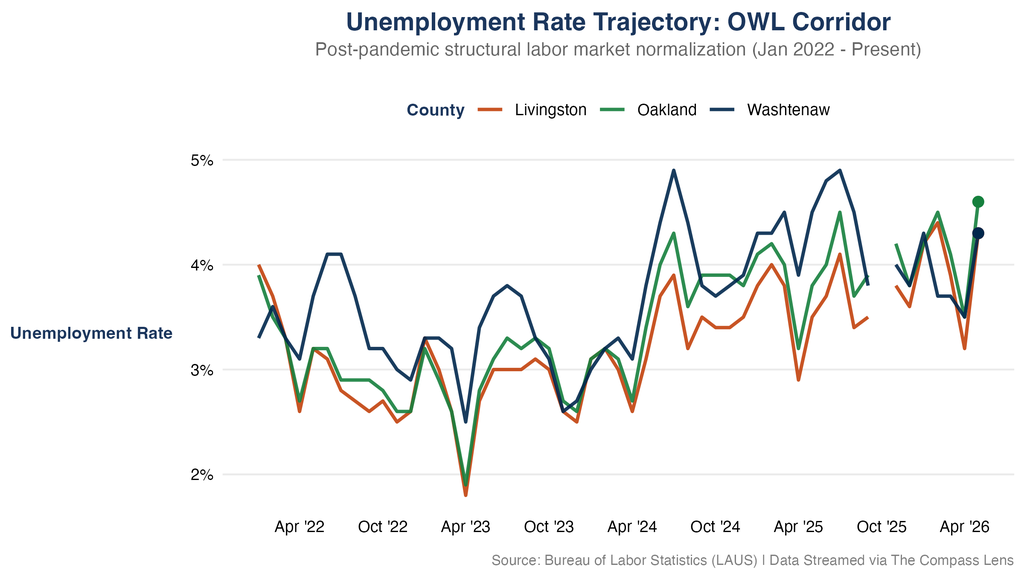

Figure 1: Unemployment Rate Horizon: Post-pandemic normalization across the OWL Corridor.

## Labor Force Capacity & Growth Scales

To observe true relative resource scaling, local labor supply capacities are indexed to a baseline of **January 2022 = 100**. This removes pure absolute scale differences (such as Oakland’s larger raw population) to trace true expansion velocities.

**Labor Force Visualization**

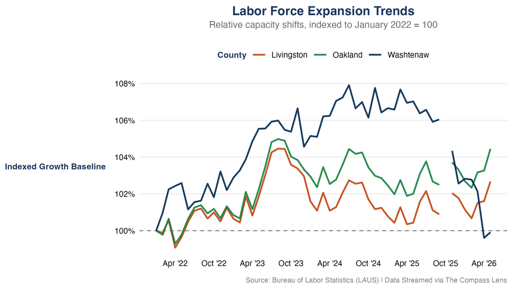

Figure 2: Labor Force Capacity: Indexed growth trends relative to the January 2022 baseline.

> **Methodological Note:** An indexed baseline of 100 means a metric value of 104 represents a clean 4% expansion in the total available labor supply pool since January 2022, regardless of raw population counts.

> **Data Note:** *Metrics reflect official LAUS/BLS benchmarks as of July 25, 2026. Historical series incorporate all revised estimates released through May 2026. In October 2025, a lapse in federal funding prohibited the collection of LAUS data. There is no LAUS data for October 2025.*

## Data Provenance & Reliability

Data streams are ingested directly from primary federal and state reporting nodes. Technical calculations, data processing, and visualization builds are automated programmatically by *The Compass Lens* core data architecture to eliminate transcription vulnerabilities.

All data, analysis, and views presented herein are independent work products of Great Lakes Center for Economics.

| Metric Component | Primary Source Agency | Spatial Resolution | Update Cadence |
| --- | --- | --- | --- |
| **Local Area Unemployment** | Bureau of Labor Statistics (LAUS) | County Level | Monthly |
| **Consumer Sentiment** | University of Michigan | National Baseline | Monthly |